# Scraping the US State 2 State Migration Data

16 August 2016

## The Scope of the Project

The current project is divided into two portions.

- The first part deals with web scraping of IRS data stats web site.
- The second consists of building a model of Truncated Singular Value Decomposition, T-SVD, to describe the data.

## Objective of Web Scraping

- Develop a proto-type python program, based on the beautiful soup package, to scrape a website.
- The tool will follow the various links into the next web page, and the next and the next…., with indifinite depths.
- Finally to download a user specific file type from a tag, href to the local HD.
- The process needs to respect the hierachical TREE structure of the links and translate them into the directory structure of the files.
- The python program has to be totally agnostic to the webpage it scrapes. All the relevant information, web links, type of tags, links to follow or avoid, etc. This makes our codes much more reusable.
- All the relevant information is passed into the program in a config file as parameters.
- Demonstrate this technique by scraping the IRS stats web site.
- The data is not large in size, but it is very dirty. The state 2 state contains 20+ years (one zip file for each year), 2000+ small files, where the state abbreviated names and the formats vary year from year.

## US state to state migration data

Due to the limit amount of time, we focus on the state \(2\) state migration data. Leaving the finer grain county 2 county migration data for future study.

Each tax season, IRS track the tax returns based on the Tax IDs/SSNs. Over time IRS collects the raw data of the tax return filing addresses assoiciated the tax payers.

This, based on tax returns, paint a picture upon how the US tax-payers migrate before the tax season ends (April 15th). So the year refered to in the talk does not mean calendar years or tax years.

## Objective: Build a simplied model to describe how US citizens/tax non-residents migrate to the other states.

A few generations ago, it was known that the US people often lived and died in the same neighborhood. It is not the case any more!

Given an out-going state name, say California, and an incoming state name, say New York, each year IRS records a total number of tax returns moving from California to New York.

So each year, there is a state to state migration matrix/dataframe, which has 51*50=2550 off diagonal entries.

Given the 20+ years (1990-2011) of yearly data, there are all together \(50000+\) parameters to describe US state residents' migration pattern.

People can migrate due to job loss, economical booming, weather, divorces, go to school, …. How do we figure out the common theme and use our 'factor choices' wisely?

## The technique used in the study

- Instead of using the raw Migration Matrix (MM), which often favors the big states like California (~40M human population), we normalize by the non-migrate tax-payers populations. To avoid favoring smaller area like D.C., we use the average of the incoming and outgoing state tax-return populations as our denominators.
- The off diagonal entries are small, it is more natural to report in bps (=0.01%).
- In applied math/Statistics, there is a well known technique of Truncated Singular Value Decomposition which can decompose a MxN matrix into \(U\LambdaV\), where \(U\) an \(MxM\) orthogonal matrix, \(\Lambda\) the diagonal matrix of positive eigenvalues, \(V\) an \(NxN\) orthogonal matrix.

## The original Migration Probability Matrix, \(MM\)

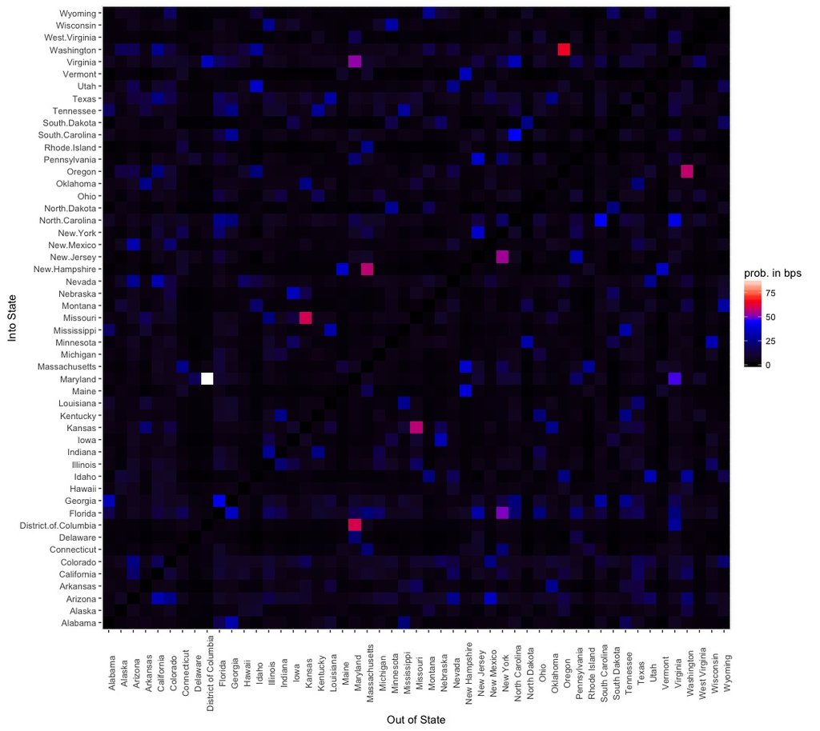

## What is driving the U.S. people to move into another state?

- SVD, the big brother of PCA, can be used to perform latent factor analysis
- Use in NLP like LSI/LSA to analyze the latent factors in the natural language semantics
- Similar in favor to the ALS, both used in designing the recommendation systems.
- Because the truncated SVDs do not always produce positive approximations, need to convert the time dependent Migration matrix to the log odds, before performing \(SVD\).

\[ log({MM(t)\over 1-MM(t)}) \sim \Pi_{off diag} (U(t) \Lambda_k(t) V(t))+\epsilon_t, \]

Choose \(k\) wisely to maximizing explanatory power, while minimizing the number of latent factors.

## Original MM Singular Value Plot

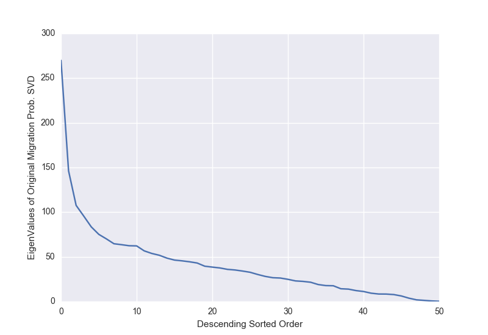

## Log Odds MM Singular Value Plot

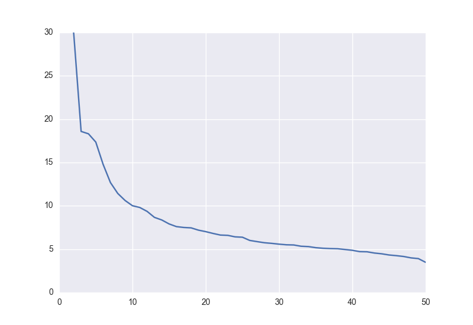

## Single Latent Factor

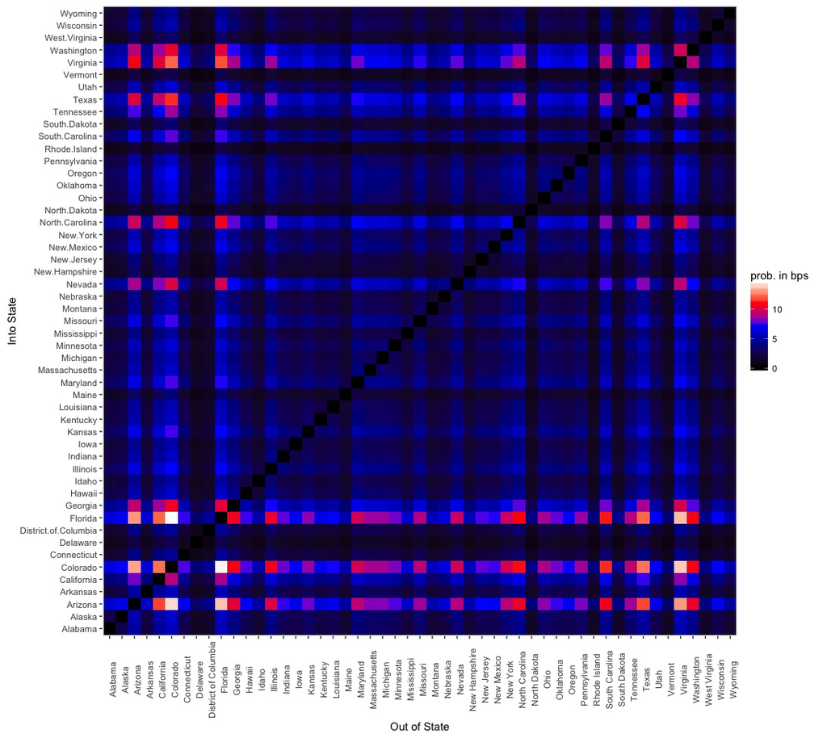

- An \(n\) dimensional vector \(x\), \((c_1,c_2,\cdots)\) is the same as a mapping on the \(n\) discrete grid points, \({\bf Z}_n\mapsto {\bf R}\).
- An \(n\times n\) matrix (or more generally \(m\times n\) matrix) \(M\) can be viewed as a mapping from the \(2D\) lattice grid to \({\bf R}\). In other words, a matrix is nothing but a mapping \(M:{\bf Z}_n \times {\bf Z}_m \mapsto{\bf R}\).
- Similar to the fact that the continous kernel function \[K(x,y) \equiv sin(2\pi(x-y)):I^2\equiv [0,1]\times [0,1]\mapsto {\bf R}\] can be expanded into \[sin(2\pi x)cos(2\pi y)-cos(2\pi x)sin(2\pi y),\] The discrete mapping \(M:{\bf Z}_n\times {\bf Z}_m\mapsto {\bf R}\) has an expansion, \[M=\lambda_1 \vec{x}_1\otimes \vec{y}_1+\lambda_2\vec{x}_2\otimes \vec{y}_2+\dots\]

## Four Latent Factors

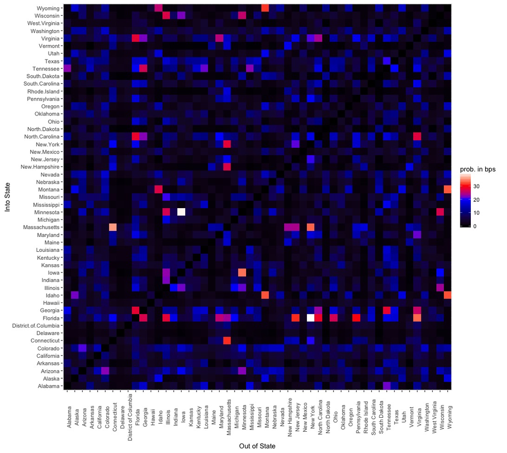

## Seven Latent Factors

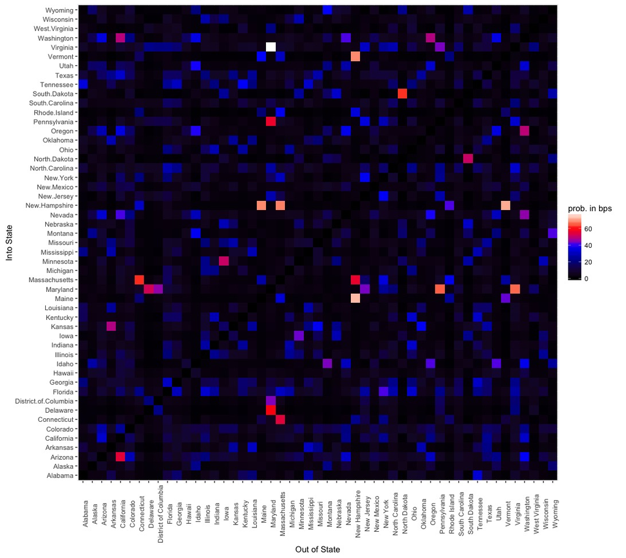

## Our Conclusion

- Even though the state residents routinely move from one state to the neighbor states, it is unlikely to be the dominate latent factor explaining residents' migration pattern.
- Fixing the migration year, the residuals \(\epsilon_t\) of the \(k\) factor truncated SVD behaves similar to IID random normal variates with a fixed standard derivation.
- The residuals from the different years seem to correlate to each other in a pattern different from those from the random normal samples. This suggests there exists temporal correlations not captured by the TSVD.
- Even though the parallel analysis of PCA suggests \(4\) latent factors, the temporal correlation pattern improves beyond \(4\), suggests a slightly richer factor structure in the data.

## The Null Model Residuals are Highly non-Normal

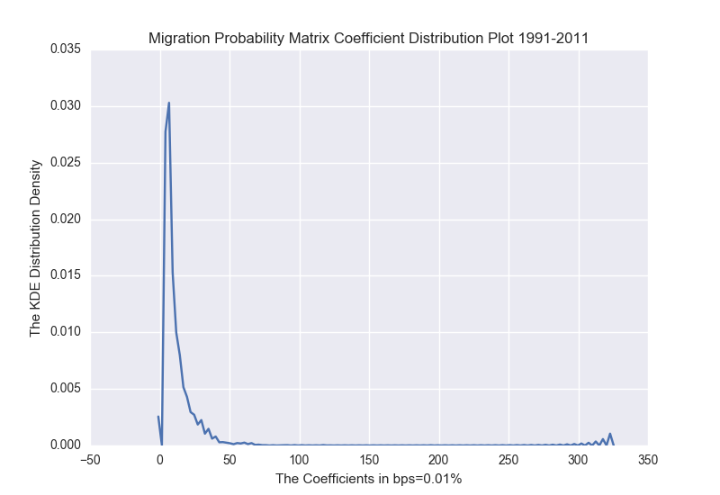

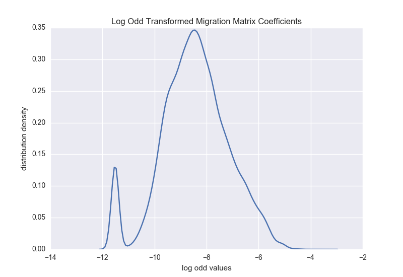

## Mean L1 Error

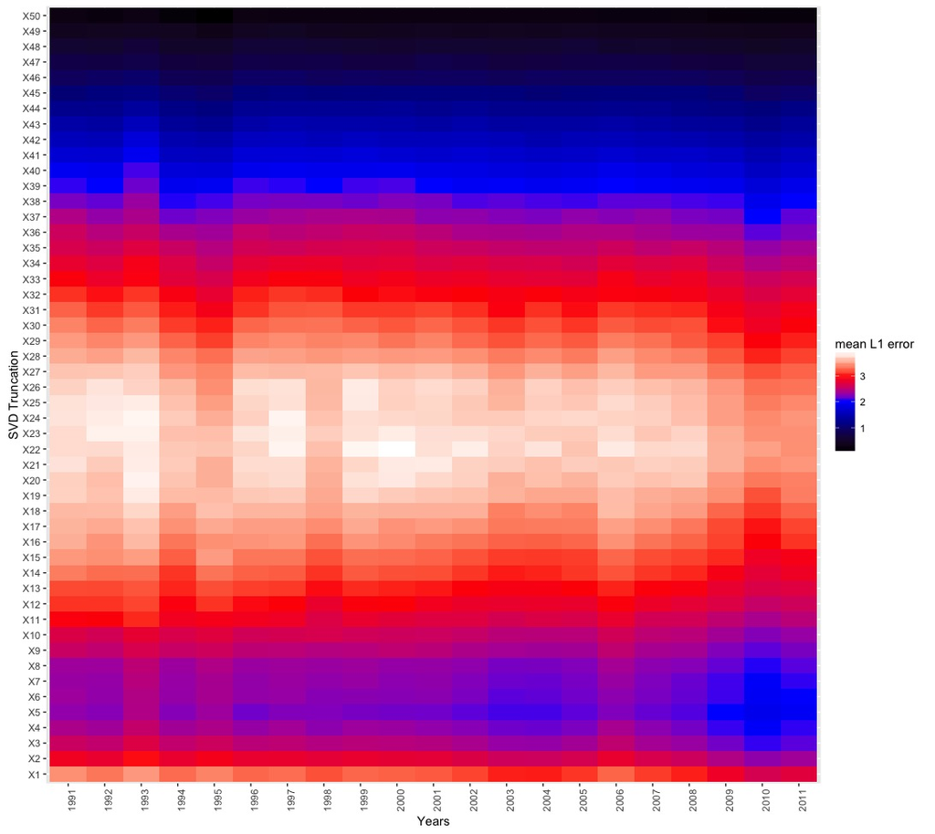

## Root Mean Square Error

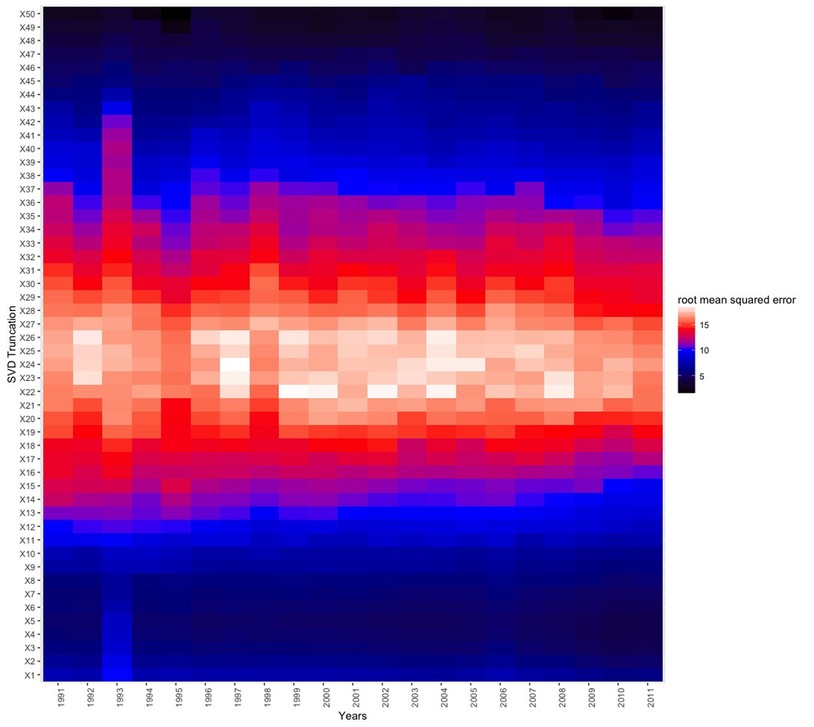